# Modelo Hibrido de Localizacao de Instalacoes Logisticas: FACILITY LOCATION PROBLEM (FLP)

WU, S. W. A.; VALLIM FILHO, A. R. A. - 2024

```r
rm(list = ls())
set.seed(1234)
library(kohonen)
require(kohonen)
library(RSNNS)
somFunc <- kohonen::som

df <- read.csv2("databases/csvUCHOA-1000.csv", header = TRUE, sep = ";")

# ----- Data Frame (DF) sem a coluna de ID -----
Data_Points <- df[2:4]
str(Data_Points)
```

```
'data.frame':   1000 obs. of  3 variables:
 $ X     : int  407 915 797 997 650 748 99 2 277 568 ...
 $ Y     : int  102 965 45 241 683 248 174 545 689 771 ...
 $ Demand: num  65.9 37.6 48.7 102.6 75.5 ...
```

```
MODELO SOM E ARQUITETURA
PREPARACAO: NORMALIZACAO dos DADOS
```

Atribuicao de Rotulos as Colunas da Matriz Normalizada

```r
data_train_matrix <- as.matrix(normalizeData(Data_Points, type = "norm"))
colnames(data_train_matrix) <- c("X", "Y", "Demanda")
Dim_X <- 23
Dim_Y <- 22
som_grid <- somgrid(xdim = Dim_X, ydim = Dim_Y, topo="rectangular")

som_model <- somFunc(data_train_matrix,
                 grid=som_grid,
                 rlen=500,
                 alpha=c(0.05,0.01),
                 keep.data = TRUE,
                 radius = 5)
```

```
NORMALIZACAO dos Prototypes / DESNORMALIZACAO dos Prototypes
```

Prototypes ==>> Posicao dos Neuronios (Dim_X x Dim_Y neuronios)

```r
Prototypes_Norm <- as.data.frame(som_model$codes)

Prototypes_DeNorm <- as.data.frame(denormalizeData(Prototypes_Norm, getNormParameters(data_train_matrix)))
colnames(Prototypes_DeNorm) <- c("X", "Y", "Demanda")
```

```
PLOTS of SOM Model
```

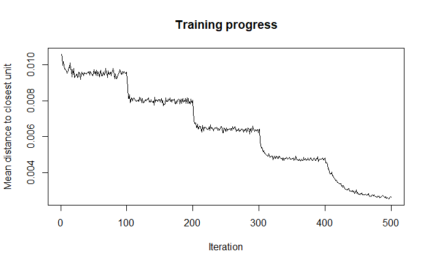

```r
plot(som_model, type="changes")
```

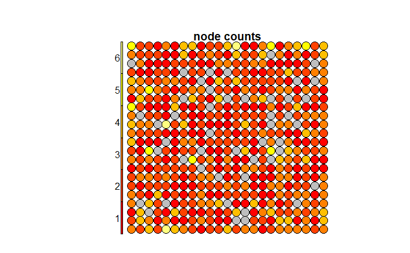

```r
#quantidade de amostras mapeadas em cada node (centroide)
plot(som_model, type="count", main = "node counts")
```

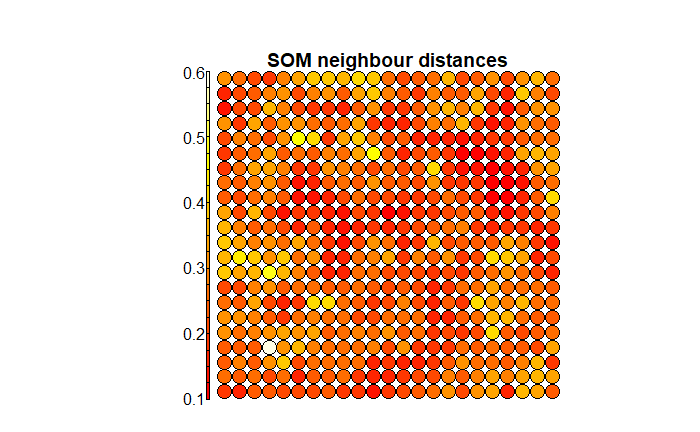

```r
plot(som_model, type="dist.neighbours", main = "SOM neighbour distances")
```

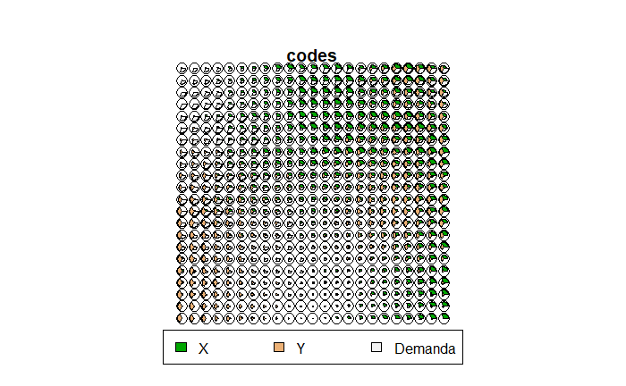

```r
plot(som_model, type="codes", main = "codes")
```

```r
# Mostra a Alocacao de Pontos aos Neuronios
som_model$unit.classif
```

[output not shown]

```
INICIALIZACAO
INICIALIZACAO de VETORES
```

- PointsDistanceVector = Vetor com Distâncias entre os Pontos de Demanda e os Prototipos e Prototypes (CANDIDATES)) para sua Media
- PrototypeDistanceVector, PrototypeDistanceVector_DeNormr = Vetor com Distâncias entre Prototypes posic a Media dos Prototypes
- Prototype_costPerSquareMeter = Vector with Costs based in Distance

```r
neuromNumber <- Dim_X * Dim_Y # No de Neuronios - usado em Prototype locations
pointsNumber <- dim(Data_Points)[1] # No de Pontos
D <- 0
PointsDistanceVector <- c()
PrototypeDistanceVector <- c()

PrototypeDistanceVector_DeNorm <- c()
Prototype_costPerSquareMeter <- c()
distanc <- function(Xc, Yc, Xw, Yw){
  distance <- sqrt((Xw-Xc)**2+(Yw-Yc)**2)
  return(distance)
}
```

```
USADO NO DATAFRAME DOS PROTOTYPES
DISTANCIA DES_NORMALIZADAS para MEDIA - com Coords Euclidianas
MEDIAS DES_NORMALIZADAS
```

```r
x_mean_Desnorm <- mean(Prototypes_DeNorm[,1]) # media x dos Prototypes
y_mean_Desnorm <- mean(Prototypes_DeNorm[,2]) # media y dos Prototypes

for(val in 1:neuromNumber){
  D_DeNorm <- distanc(Prototypes_DeNorm$X[[val]], Prototypes_DeNorm$Y[[val]],
               x_mean_Desnorm, y_mean_Desnorm)
  PrototypeDistanceVector_DeNorm[val] <- D_DeNorm
}
```

DEFINICAO DO DATAFRAME DE PONTOS DE DEMANDA # >>>>> “PONTOS de DEMANDA” - Atributos: X, Y, Neuronio de Alocacao e Demanda

```r
Points_Locations <- data.frame(
  id = 1:pointsNumber,
  x = Data_Points[,1],
  y = Data_Points[,2],
  localiz = as.matrix(som_model$unit.classif), # Ptos vs Neuronios
  Demand = Data_Points[,3]
)
# View(Points_Locations) # X, Y, Neuronio, Demanda
Average_Demand <- sum(Data_Points[,3])/neuromNumber
Average_Demand
```

```
[1] 196.3447
```

```r
#sum(Data_Points[,3])
```

# —– Comparacao de Metadados —–

# str(Points_Locations) # X, Y, Neuronio, Demanda

```
Soma DEMANDA (DESNORMALIZADA) de cada PROTOTIPO
```

```r
Protot_Demand <- vector(length = neuromNumber)
for(i in 1:neuromNumber){
  for(j in 1:pointsNumber){
    if(Points_Locations$localiz[j] == i){
      Protot_Demand[i] <- Protot_Demand[i] + Points_Locations$Demand[j]
    }
  }
}
```

# ===>>> Se Demanda = 0 ==>> Demanda = Infinito!!

# for(i in 1:neuromNumber){

# if(Protot_Demand[i] == 0){

# Protot_Demand[i] <- 999999999}

#} # Protot_Demand length(Protot_Demand)

```
Calculo de SIZE e COST por PROTOTIPO (CANDIDATE
```

# — Inicializa Vetores —

```r
Prototype_costs <- vector(length = neuromNumber)
Prototype_size  <- vector(length = neuromNumber)
```

```
PARAMETROS DE CUSTO: Define Densidade de UNIDADES/m2 ==>> UNIDADE = ton, m3, etc.
Calculo de CUSTO FIXO por Prototipo (CANDIDATO)
```

# ……….. Revisado com parametros definidos em 01/03

```r
sq_meter_per_Unit <- 5.6    # Vide Planilha de Densidades ==>> 8,3m2/ton
Cost_per_sq_meter <- 27  # Vide Planilha de Densidades
Cost_per_Unit <- 31.83    # Vide Planilha de Densidades ==>> 42,50/ton

for(i in 1:neuromNumber){
  Prototype_size[i] <- (Protot_Demand[i] * sq_meter_per_Unit)
  Prototype_costs[i] <- (Protot_Demand[i] * Cost_per_Unit
                      + Prototype_size[i]* Cost_per_sq_meter)
}
```

# Dados de Prototypes (com “dist_to_mean” DES_NORMALIZADA)

# >>>>> “PROTOTIPOS” <<<<<

# Atributos: X, Y, Dist p Media, $/m2, Demanda, Area e Custo

```r
Prototype_id <- neuromNumber # No Total de Neuronios

Prototype_locations <- data.frame(
  id = 1:Prototype_id,
  x = Prototypes_DeNorm$X,
  y = Prototypes_DeNorm$Y,
  dist_to_mean = PrototypeDistanceVector_DeNorm, #dist of each Prototype to all Prototypes mean
  # cost_per_square_meter = Prototype_costPerSquareMeter, #cost based on dist_to_mean quartiles (line 162)
  total_Demand = Protot_Demand,
  Prototype_size = Prototype_size, #size based on Demand
  Prototype_costs = Prototype_costs #cost based on Prototype_size and cost_per_square_meter
)

Tot_Demand <- sum(Protot_Demand)
Tot_Demand
```

```
[1] 99350.4
```

```r
Tot_Facilities_size <- Tot_Demand * sq_meter_per_Unit
Tot_Facilities_size
```

```
[1] 556362.2
```

```r
p_max <- 0.2*pointsNumber
Fixed_Facility_Dem_Cost <- Tot_Demand/(p_max)*Cost_per_Unit
Fixed_Facility_Size_Cost <- Tot_Facilities_size/(p_max) * Cost_per_sq_meter
Fixed_Facility_Cost <- Fixed_Facility_Dem_Cost + Fixed_Facility_Size_Cost
Fixed_Facility_Dem_Cost
```

```
[1] 15811.62
```

```r
Fixed_Facility_Size_Cost
```

```
[1] 75108.9
```

```r
Fixed_Facility_Cost
```

```
[1] 90920.52
```

| CALCULOS DE CUSTO INICIANDO |
| --- |

```
MATRIZ de CUSTOS de TRANSPORTE: PONTOS-CANDIDATOS

FUNCAO para CALCULAR OS CUSTOS de TRANSPORTE
          Com DISTANCIAS EUCLIDIANAS
DIST ENTRE PONTO i E PROT j
```

```r
Custo_Unitario_de_Transporte <- 0.36225  # <<<=== [ $/ton.km ]
# fonte: ANTT 2024 - Carga Geral(item 5) - Lotação de Alto Desempenho - 2 eixos
# R$/km = 2,898... Capac = 8t ==>>> $/t.km - 2,898/8 = 0,3625
transportcost_func <- function(i, j) {
  Point <-  Points_Locations[i, ]
  Prototype <- Prototype_locations[j, ]
  # calcula o custo de transporte com Dist. Euclidiana
  # return(sqrt((Point$x-Prototype$x)**2+(Point$y-Prototype$y)**2)
  #        * (2.5/25) * (Prototype$Prototype_size * 12/0.3))
  return(sqrt((Point$x-Prototype$x)**2+(Point$y-Prototype$y)**2)
         * (Custo_Unitario_de_Transporte) * (Point$Demand))
}
```

```
CRIA MATRIZ COM CUSTOS TOTAIS de TRANSPORTE: PONTOS-CANDIDATOS
```

# Calcula Custo de Transporte de cada Ponto a todos os Candidatos

# Usa Funcao “transport_cost_func” para esse Calculo

# E gera a Matriz de Custos chamada de “transport_cost”

# —– Com DISTANCIAS EUCLIDIANAS - DESNORMALIZADAS —–

```r
transportCostMatrixFact <- function(){
  transport_cost <- matrix(nrow = pointsNumber, ncol = neuromNumber)
  for(row in 1:pointsNumber){
    for(col in 1:neuromNumber){
      transport_cost[row, col] <- transportcost_func(row, col)
    }
  }
  return(transport_cost)
}
```

```
CUSTO de TRANSPORTE USADO no MODELO MILP
```

# — Transformacao de Matriz de Custos em DF —

```r
transport_cost <- as.data.frame(transportCostMatrixFact())
```

```
MONTAGEM DO MODELO MILP
```

j ==>> prototipo especifico i ==>> ponto de demanda especifico # masked functions: and, mod, or

```r
library(ompr)
library(magrittr)

model_MIP <- MIPModel() %>%

  # ===>>> VARIABLES DEFINITION: x[i,j]={0,1} and y[j]={0,1} ----------

  # x[i,j] = 1, iff Demand Point i gets assigned to Prototype j
  add_variable(x[i, j], i = 1:pointsNumber, j = 1:neuromNumber, type = "binary") %>%

  # y[j] = 1, iff Prototype j is built (active)
  add_variable(y[j], j = 1:neuromNumber, type = "binary") %>%

  # set_objective(sum_expr(transportcost_func(i, j) * x[i, j], i = 1:pointsNumber, j = 1:neuromNumber) +  #trocar por transport_cost[i,j]
  #                 sum_expr(Prototype_costs[j] * y[j], j = 1:neuromNumber), "min") %>%        #trocar por Prototype_costs[j]

  # ===>>> OBJECTIVE FUNCTION -------------
    # set_objective(sum_expr(transport_cost[i, j] * x[i, j], i = 1:pointsNumber, j = 1:neuromNumber) +    #trocar por transport_cost[i,j]
    #               sum_expr(Prototype_costs[j] * y[j], j = 1:neuromNumber), "min") %>%      #trocar por Prototype_costs[j]

    # set_objective(sum_expr(transport_cost[i, j] * x[i, j], i = 1:pointsNumber, j = 1:neuromNumber) +
    #                 sum_expr(Average_Protot_Cost * y[j], j = 1:neuromNumber), "min") %>%

   # set_objective(sum_expr(transport_cost[i, j] * x[i, j], i = 1:pointsNumber, j = 1:neuromNumber) +
   #                sum_expr(Fixed_Protot_Cost * y[j], j = 1:neuromNumber), "min") %>%

  set_objective(sum_expr(transport_cost[i, j] * x[i, j], i = 1:pointsNumber, j = 1:neuromNumber) +
                  sum_expr(Fixed_Facility_Cost * y[j], j = 1:neuromNumber), "min") %>%

  # ===>>> CONSTRAINTS -------------
# Every Demand Point needs to be assigned to a Prototype
  add_constraint(sum_expr(x[i, j], j = 1:neuromNumber) == 1, i = 1:pointsNumber) %>%

# If a Demand Point is assigned to a Prototype, the Prototype must be Active
  add_constraint(x[i,j] <= y[j], i = 1:pointsNumber, j = 1:neuromNumber)

model_MIP
```

```
Mixed integer linear optimization problem
Variables:
  Continuous: 0
  Integer: 0
  Binary: 506506
Model sense: minimize
Constraints: 507000
```

```
RODAR O MODELO MILP - SOLUCAO OTIMA - RESULTADOS
```

# OBS: A variavel Y define os Candidatos escolhidos para Facilities

```r
library(ompr.roi)
library(ROI.plugin.glpk)

result <- solve_model(model_MIP, with_ROI(solver = "glpk", verbose = TRUE))
```

[output not shown]

```r
result$objective_value # Valor da Funcao Objetivo
```

```
[1] 3771679
```

```r
result$solution        # Valor das Variaveis Binarias: x e Y
```

[output not shown]

[output cut: 72 more lines]

[output not shown]

```r
result$status          # Atingiu Solucao Otima (S/pointsNumber).. Sucesso
```

```
[1] "success"
```

```r
result$model           # Caracterisiticas do MOdelo : MILP Model
```

[output not shown]

| ————————-REVISAR PARA QUE ESCOLHA MAIS DE———————– |
| --- |

```
SOLUCAO OTIMA: Facilities, Alocacao e Custos
```

Yj ==>> Candidates_Selection = List of Selected Candidates

```r
Y_j <- vector(length = neuromNumber)
for(i in 1:neuromNumber){
  Y_selected <- result$solution[neuromNumber*pointsNumber + i]
  Y_j[i] <- Y_selected
}
Y_j # Yj
```

[output not shown]

```r
Y_j_DF <- as.data.frame(Y_j)

# ===>>> p = # of Active Candidates
active_facilities=0
for (i in 1:neuromNumber) {
  active_facilities <- active_facilities + Y_j[i]
}
active_facilities
```

```
[1] 8
```

# ===>>> CUSTO TOTAL de Implantacao das FACILITIES

```r
Facilities_Opt_Cost=0
for (i in 1:neuromNumber) {
  Facilities_Opt_Cost <- Facilities_Opt_Cost + Fixed_Facility_Cost * Y_j[i] # Candidates_Selection[i]

  # Facilities_Opt_Cost <- Facilities_Opt_Cost + Prototype_locations$Prototype_costs[i] * Candidates_Selection_DF$Candidates_Selection[i]
}
Facilities_Opt_Cost
```

[output not shown]

```r
# ===>>> X_ij = Matriz de Alocacao "Pontos-Facilities"
X_ij <- matrix(result$solution, ncol = neuromNumber, nrow=pointsNumber, byrow=T)
dim(X_ij)
```

[output not shown]

```r
dim(transport_cost)
```

[output not shown]

```r
# ===>>> CUSTO TOTAL de TRANSPORTE: "Pontos-Facilities"
Transp_Opt_Cost=0
for (i in 1:pointsNumber) {
  for (j in 1:neuromNumber){
    Transp_Opt_Cost <- Transp_Opt_Cost + transport_cost[i, j] * X_ij[i, j]
  }
}
Transp_Opt_Cost
```

```
[1] 2955433
```

# ===>>> CUSTO TOTAL da OPERACAO = Custo de TRANSPORTE + Custo de FACILITIES

```r
Total_Opt_Cost <- Transp_Opt_Cost + Facilities_Opt_Cost
Total_Opt_Cost
```

```
[1] 3771679
```

# ===>> *** CHECAGEM ***: CUSTO TOTAL da OPERACAO via MODELO

```r
Total_Opt_Cost_Model <- result$objective_value
Total_Opt_Cost_Model
```

```
[1] 3771679
```

# ===>>> PESOS % dos CUSTOS

```r
Weight_Facilities_Opt_Cost <- Facilities_Opt_Cost/Total_Opt_Cost*100
Weight_Facilities_Opt_Cost
```

```
[1] 21.64146
```

```r
Weight_Transp_Opt_Cost <- Transp_Opt_Cost/Total_Opt_Cost*100
Weight_Transp_Opt_Cost
```

```
[1] 78.35854
```

```
GERAR MATRIZ COMPLETA DE SOLUCOES; Xij + Yj
```

# ===>>> X_ij = Matriz de Alocacao “Pontos-Facilities”

# ===>>> Y_j = Vetor de Candidatos Selecionados

```
Unir X_ij e Y_j
Criar Matriz Xij_Yj
```

```r
Xij_Yj <- X_ij
dim(Xij_Yj)
```

```
[1] 523  12
```

```r
Xij_Yj =  rbind(Xij_Yj, Y_j)
dim(Xij_Yj)
```

```
[1] 524  12
```

```r
# Teste
Xij_Yj[110,]
```

```
 [1] 0 0 0 0 1 0 0 0 0 0 0 0
```

```r
# Append de uma Linha a mais na Matriz com o Valor da F. Objetivo
# O valor fica repetido em todas as posições da Linha
K_N = 0
c<- c()
for(Col in 1:neuromNumber){
  K_N <- K_N + 1
  c <- append(c, result$objective_value, after = K_N)
  }
c
```

```
 [1] 3771679 3771679 3771679 3771679 3771679 3771679 3771679 3771679 3771679 3771679 3771679 3771679
```

```r
Xij_Yj_FObj <- Xij_Yj
dim(Xij_Yj_FObj)
```

```
[1] 524  12
```

```r
F_Obj <- c
Xij_Yj_FObj =  rbind(Xij_Yj_FObj, F_Obj)
dim(Xij_Yj_FObj)
```

```
[1] 525  12
```

```r
write.csv(Xij_Yj_FObj, "Solution_Test_Xij_Yj_FObj.csv")
Data_SolutionXij_Yj_FObj<- read.csv("Solution_Test_Xij_Yj_FObj.csv", sep = ",", header = T)
str(Data_SolutionXij_Yj_FObj)
```

```
'data.frame':   525 obs. of  13 variables:
 $ X  : chr  "" "" "" "" ...
 $ V1 : num  0 0 0 1 0 1 0 0 0 0 ...
 $ V2 : num  0 0 0 0 0 0 0 0 0 0 ...
 $ V3 : num  0 0 0 0 0 0 0 0 0 0 ...
 $ V4 : num  1 0 1 0 1 0 0 0 0 0 ...
 $ V5 : num  0 0 0 0 0 0 0 0 0 0 ...
 $ V6 : num  0 0 0 0 0 0 0 0 0 0 ...
 $ V7 : num  0 0 0 0 0 0 1 0 1 0 ...
 $ V8 : num  0 0 0 0 0 0 0 0 0 0 ...
 $ V9 : num  0 0 0 0 0 0 0 0 0 0 ...
 $ V10: num  0 0 0 0 0 0 0 0 0 0 ...
 $ V11: num  0 1 0 0 0 0 0 0 0 1 ...
 $ V12: num  0 0 0 0 0 0 0 1 0 0 ...
```

```
          OUTRA ALTERNATIVA
NAO E NECESSARIO RODAR ESTA ALTERNATIVA
          VETOR de SOLUCOES
              Xij + Yj
      Total de Posicoes = pointsNumber*neuromNumber = neuromNumber
```

```r
Candidates_Solution <- c()
K_N <- 0
Lsup <- pointsNumber*neuromNumber + neuromNumber
for (i in 1:Lsup) {
  if (i==1)  {K_N <- K_N + i }
  else       {K_N <- K_N + i + 1}
  Candidates_Solution<- append(Candidates_Solution, result$solution[i], after = K_N)
}

# Teste... Print de Yj ultimas posicoes do vetor
length(Candidates_Solution)
```

```
[1] 6288
```

```r
Candidates_Solution[1309:1320]
```

```
 x[110,1]  x[110,2]  x[110,3]  x[110,4]  x[110,5]  x[110,6]  x[110,7]  x[110,8]  x[110,9] x[110,10] x[110,11] x[110,12]
        0         0         0         0         1         0         0         0         0         0         0         0
```

```r
write.csv(Candidates_Solution, "Solution_Test113.csv")
Data_Solution1<- read.csv("Solution_Test113.csv", sep = ",", header = T)
str(Data_Solution1)
```

```
'data.frame':   6288 obs. of  2 variables:
 $ X: chr  "x[1,1]" "x[1,2]" "x[1,3]" "x[1,4]" ...
 $ x: int  0 0 0 1 0 0 0 0 0 0 ...
```

```
GERACAO de MATRIZ de SOLUCOES
```

```r
Solution_Matrix <- matrix(nrow = pointsNumber+1, ncol = neuromNumber)
dim(Solution_Matrix)
```

```
[1] 524  12
```

```r
# N_Variables <- pointsNumber*neuromNumber + neuromNumber
N_Variable <- 0
N_Row <- pointsNumber + 1
N_Col <- neuromNumber
for(Row in 1:N_Row){
  for(Col in 1:N_Col){
  N_Variable <- N_Variable + 1
  Solution_Matrix[Row, Col] <- result$solution[N_Variable]}}

# Append de uma Linha a mais na Matriz com o Valor da F. Objetivo
# O valor fica repetido em todas as posições da Linha
K_N = 0
c<- c()
for(Col in 1:N_Col){
  K_N <- K_N + 1
  c <- append(c, result$objective_value, after = K_N)}
c
```

```
 [1] 3771679 3771679 3771679 3771679 3771679 3771679 3771679 3771679 3771679 3771679 3771679 3771679
```

```r
F_Obj <- c
Solution_Matrix =  rbind(Solution_Matrix, F_Obj)
dim(Solution_Matrix)
```

```
[1] 525  12
```

```r
# Teste
Solution_Matrix[N_Row+1,]
```

```
 [1] 3771679 3771679 3771679 3771679 3771679 3771679 3771679 3771679 3771679 3771679 3771679 3771679
```

```r
Solution_Matrix[111,]
```

```
 [1] 0 0 0 1 0 0 0 0 0 0 0 0
```

```r
write.csv(Solution_Matrix, "Solution_Matrix10011.csv")
Matrix_Solution10011<- read.csv("Solution_Matrix10011.csv", sep = ",", header = T)
str(Matrix_Solution10011)
```

```
'data.frame':   525 obs. of  13 variables:
 $ X  : chr  "" "" "" "" ...
 $ V1 : num  0 0 0 1 0 1 0 0 0 0 ...
 $ V2 : num  0 0 0 0 0 0 0 0 0 0 ...
 $ V3 : num  0 0 0 0 0 0 0 0 0 0 ...
 $ V4 : num  1 0 1 0 1 0 0 0 0 0 ...
 $ V5 : num  0 0 0 0 0 0 0 0 0 0 ...
 $ V6 : num  0 0 0 0 0 0 0 0 0 0 ...
 $ V7 : num  0 0 0 0 0 0 1 0 1 0 ...
 $ V8 : num  0 0 0 0 0 0 0 0 0 0 ...
 $ V9 : num  0 0 0 0 0 0 0 0 0 0 ...
 $ V10: num  0 0 0 0 0 0 0 0 0 0 ...
 $ V11: num  0 1 0 0 0 0 0 0 0 1 ...
 $ V12: num  0 0 0 0 0 0 0 1 0 0 ...
```

```
        PLOTS
  PRECISA AJUSTAR PARA USAR O MÉTODO NOVO ACIMA TAMBEM
```

```r
library(ggplot2)
require(ggplot2)

x11()

grid_size <- 0
#principal PLOT
p <- ggplot(Points_Locations, aes(x, y)) +
  geom_point() +
  geom_point(data = Prototype_locations, color = "red", alpha = 0.5, shape = 17) +
  scale_x_continuous(limits = c(0, 1000)) +
  scale_y_continuous(limits = c(0, 1000)) +
  theme(axis.title = element_blank(),
        axis.ticks = element_blank(),
        axis.text = element_blank(), panel.grid = element_blank())
p + ggtitle("Prototype Location Problem",
            "Black dots are customers. Light red triangles show potential Prototypes locations.")
```

```
    SEGUNDO PLOTS NAO FUNCIONANDO
```

```r
suppressPackageStartupMessages(library(dplyr))
matching <- result %>%
  get_solution(x[i,j]) %>%
  filter(value > .9) %>%
  select(i, j)

x11()

#add the assignments to the previous plot
plot_assignment <- matching %>%
  inner_join(Points_Locations, by = c("i" = "id")) %>%
  inner_join(Prototype_locations, by = c("j" = "id"))
customer_count <- matching %>% group_by(j) %>% summarise(pointsNumber = n()) %>% rename(id = j)

###### problema com fixed cost (o custo fixo deste código varia)
#armazéns escolhidos
plot_Prototypes <- Prototype_locations %>%
  mutate(costs = Prototype_costs) %>%
  inner_join(customer_count, by = "id") %>%
  filter(id %in% unique(matching$j))

p <- p +
  geom_segment(data = plot_assignment, aes(x = x.y, y = y.y, xend = x.x, yend = y.x)) +
  geom_point(data  = plot_Prototypes, color = "red", size = 3, shape = 17) +
  ggrepel::geom_label_repel(data  = plot_Prototypes,
                            aes(label = paste0("fixed costs:", costs, "; customers: ", pointsNumber )),
                            size = 3, nudge_y = 20) +
  ggtitle(paste0("Cost optimal Prototype Locations and customer assignment"),
          "Big red triangles show Prototypes that will be built, light red are unused Prototype
          locations. Dots represent customers served by the respective Prototypes.")

#fixed costs for setting up the 4 Prototypes:
sum(Prototype_costs[unique(matching$j)])
```

```
[1] 5609613
```

Pegar resultados

```r
setwd("C:/Users/samue/Documents/Mestrado/defesa/codigo/resultados/plots-ret")
plotfilename <- paste0(as.character(pointsNumber), "-" ,as.character(Dim_X), "x",as.character(Dim_Y), ".png")
ggsave(
  filename = plotfilename,
  plot = p,
  width = 14,       # em polegadas
  height = 10,
  dpi = 300         # alta qualidade (ideal para impressão)
)

model_MIP
```

[output not shown]

```r
Facilities_Opt_Cost
```

```
[1] 816246.6
```

```r
Transp_Opt_Cost
```

```
[1] 2955433
```

```r
active_facilities
```

```
[1] 8
```

#fases FASE 1: >>>>> GERACAO DE PROTOTIPOS (CANDIDATOS) <<<<< O modelo gera Prototipos por meio de uma rede SOM, ===>>> PROTOTIPOS = NEURONIOS do SOM Os Prototipos serao Locais CANDIDATOS a Instalacoes Logisticas ===>>> PROTOTIPOS = NEURONIOS do SOM = CANDIDATOS

FASE 2: >>>>> RESOLUCAO do FLP <<<<< Os Prototipos serao Dados de Entrada de um Modelo MILP O modelo MILP vai encontrar uma Solucao Otima para o FLP Na Solucao Otima os melhores Locais Candidatos sao selecionados Solucao Otima contem: ==>> Candidatos Descartados e Ativados ==>> Alocacao dos Pontos de Demanda a cada Candidato Ativo ==>> Valor da Funcao Objetivo